# O pacote caret

Oscar J. O. Ayala

# Introdução

Os muitos dos algoritmos de Machine Learning (ML) são implementados no R. Porém, são desenvolvidos por diferentes pacotes, autores e sintaxes. O pacote *caret* tenta consolidar essas diferenças e fornecer consistência. Atualmente inclui *237* métodos diferentes que estão resumidos no [manual do pacote](https://topepo.github.io/caret/available-models.html).

# Dados

Usa-se o conjunto de dados do pacote `mnist_27` querendo-se constriur um algoritmo que classifique as saídas $Y = 2 \text{ ou } 7$ com dois regressores $(X_1, X_2)$.

```r
library(tidyverse)
library(dslabs)
data("mnist_27")
```

```r
train <- mnist_27$train
teste <- mnist_27$test
head(train, 5) %>% knitr::kable(digits = 2, caption = "Tabela 1. Conjunto train")
```

Tabela 1. Conjunto train

| y | x_1 | x_2 |
| --- | --- | --- |
| 2 | 0.04 | 0.18 |
| 7 | 0.16 | 0.09 |
| 2 | 0.02 | 0.28 |
| 2 | 0.14 | 0.22 |
| 7 | 0.39 | 0.37 |

```r
head(teste, 5) %>% knitr::kable(digits = 2, caption = "Tabela 2. Conjunto teste")
```

Tabela 2. Conjunto teste

| y | x_1 | x_2 |
| --- | --- | --- |
| 2 | 0.15 | 0.26 |
| 7 | 0.28 | 0.35 |
| 7 | 0.29 | 0.44 |
| 7 | 0.20 | 0.11 |
| 7 | 0.22 | 0.40 |

## A função `caret::train`.

Essa função permite aplicar diferentes algoritmo usando sintaxes semelhantes,

```r
# ajustar o modelo
train_knn <- caret::train(y ~ ., method = "knn", data = train)
train_glm <- caret::train(y ~ ., method = "glm", data = train)
```

```r
# previsão conjunto teste
hat_knn <- predict(train_knn, teste, type = "raw")
hat_glm <- predict(train_glm, teste, type = "raw")
```

```r
# precisao
caret::confusionMatrix(hat_knn, teste$y)$overall[["Accuracy"]]
```

```
## [1] 0.84
```

```r
caret::confusionMatrix(hat_glm, teste$y)$overall[["Accuracy"]]
```

```
## [1] 0.75
```

## Validação cruzada

Quando um algoritmo inclui um parâmetro de ajuste, `train` usa automaticamente a validação cruzada para decidir entre alguns valores padrão.

Também, se pode ver uma espercificação clara do modelo,

```r
modelLookup("knn") %>% knitr::kable()
```

| model | parameter | label | forReg | forClass | probModel |
| --- | --- | --- | --- | --- | --- |
| knn | k | #Neighbors | TRUE | TRUE | TRUE |

Também é possível obter um gráfico da validação cruzada,

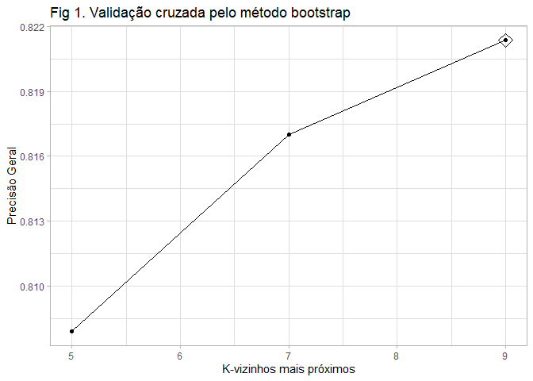

```r
ggplot2::ggplot(train_knn, highlight = TRUE) +
  ggplot2::labs(title = "Fig 1. Validação cruzada pelo método bootstrap", x = "K-vizinhos mais próximos", y = "Precisão Geral") +
  ggplot2::theme_light()
```

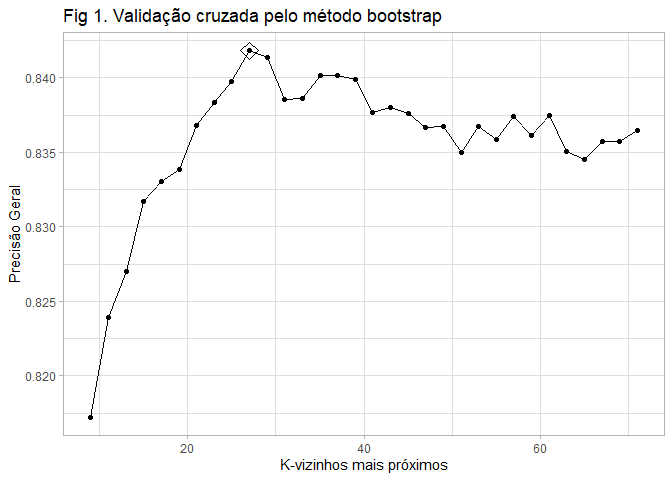

```r
# Se ajusta para 30 valores de k
set.seed(2008)
train_knn <- train(y ~ ., method = "knn",
                   data = train,
                   tuneGrid = data.frame(k = seq(9, 71, 2)))
ggplot(train_knn, highlight = TRUE) +
  ggplot2::labs(title = "Fig 1. Validação cruzada pelo método bootstrap", x = "K-vizinhos mais próximos", y = "Precisão Geral") +
  ggplot2::theme_light()
```

O parâmetro que maximizou foi $k = 27$,

```r
train_knn$bestTune
```

```
##     k
## 10 27
```

O modelo com melhor desempenho foi,

```r
train_knn$finalModel
```

```
## 27-nearest neighbor model
## Training set outcome distribution:
##
##   2   7
## 379 421
```

Com o modelo optimizado acima se avalia com o conjunto teste, a função `stats::predict` esse modelo final,

```r
confusionMatrix(predict(train_knn, mnist_27$test, type = "raw"),
                mnist_27$test$y)$overall["Accuracy"]
```

```
## Accuracy
##    0.835
```

Algumas estatísticas úteis são:

```r
train_knn$results %>% head(n = 11) %>% knitr::kable()
```

| k | Accuracy | Kappa | AccuracySD | KappaSD |
| --- | --- | --- | --- | --- |
| 9 | 0.8172290 | 0.6329529 | 0.0185599 | 0.0368481 |
| 11 | 0.8239027 | 0.6463630 | 0.0170575 | 0.0338712 |
| 13 | 0.8270221 | 0.6525031 | 0.0209938 | 0.0419648 |
| 15 | 0.8317305 | 0.6620640 | 0.0162979 | 0.0325222 |
| 17 | 0.8330408 | 0.6647175 | 0.0152254 | 0.0306806 |
| 19 | 0.8338554 | 0.6664527 | 0.0124588 | 0.0250903 |
| 21 | 0.8368334 | 0.6723935 | 0.0141425 | 0.0284520 |
| 23 | 0.8383466 | 0.6753496 | 0.0142509 | 0.0285769 |
| 25 | 0.8397586 | 0.6782053 | 0.0145237 | 0.0292234 |
| 27 | 0.8418153 | 0.6823317 | 0.0123184 | 0.0247093 |
| 29 | 0.8414019 | 0.6815281 | 0.0154050 | 0.0310790 |